# Practical Machine Learning Project

```r
knitr::opts_chunk$set(fig.width=6, fig.height=3, fig.path='Figs/')
```

## Introduction

Using devices such as Jawbone Up, Nike FuelBand, and Fitbit it is now possible to collect a large amount of data about personal activity relatively inexpensively. These type of devices are part of the quantified self movement - a group of enthusiasts who take measurements about themselves regularly to improve their health, to find patterns in their behavior, or because they are tech geeks. One thing that people regularly do is quantify how much of a particular activity they do, but they rarely quantify how well they do it. In this project, our goal is to use data from accelerometers on the belt, forearm, arm, and dumbell of 6 participants.

## Download Packages and Read Data

```r
library(caret)
library(randomForest)
```

```r
library(rpart)
library(rpart.plot)
train <- read.csv("pml-training.csv")
test <- read.csv ("pml-testing.csv")
```

## Data Preparation and Cleaning

The train data has 160 variables and 19,622 cases. We split the train data set into a training set and test set with 75% for training and 25% for testing.

```r
trainingIndex <- createDataPartition(train$classe,list=FALSE,p=0.75)
trainset <- train[trainingIndex, ]
testset <- train[-trainingIndex, ]
dim(train)
```

```
## [1] 19622   160
```

```r
dim(test)
```

```
## [1]  20 160
```

```r
trainset <- trainset[, colSums(is.na(trainset))==0]
testset <- testset[, colSums(is.na(testset))==0]
```

In the second step, we remove observations with near zero values.This brings down the number of variables to 59.

```r
nzv<-nearZeroVar(trainset)
trainset <- trainset[-nzv]
testset <- testset[-nzv]
```

In the next step, we remove the first six columns which will have no impact on our prediction model.This brings down the number of variables to 53.

```r
trainset <- trainset[, -(1:6)]
testset <- testset[, -(1:6)]
```

## Data Model

We use the random forest method with 5-fold cross-validation.

```r
set.seed(12345)
controlRf <- trainControl(method="cv",5)
modelfit <- train(classe ~.,data=trainset,method="rf",trControl=controlRf,ntree=200)
modelfit
```

```
## Random Forest
##
## 14718 samples
##    52 predictor
##     5 classes: 'A', 'B', 'C', 'D', 'E'
##
## No pre-processing
## Resampling: Cross-Validated (5 fold)
## Summary of sample sizes: 11774, 11774, 11775, 11774, 11775
## Resampling results across tuning parameters:
##
##   mtry  Accuracy   Kappa      Accuracy SD  Kappa SD
##    2    0.9919145  0.9897712  0.001883536  0.002384030
##   27    0.9924582  0.9904601  0.001583066  0.002002575
##   52    0.9867505  0.9832387  0.003088247  0.003908554
##
## Accuracy was used to select the optimal model using  the largest value.
## The final value used for the model was mtry = 27.
```

We plot the error rate of prediction for the 200 trees.

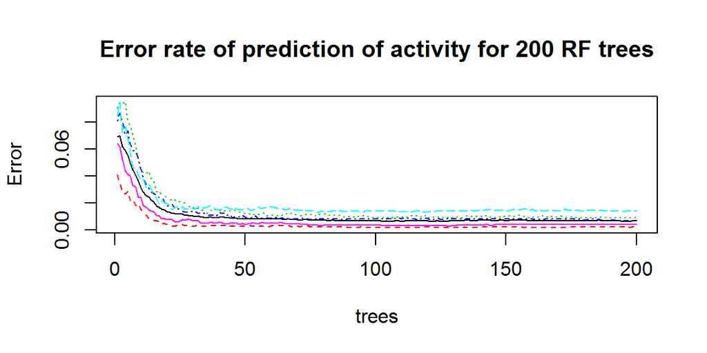

```r
plot(modelfit$finalModel,main="Error rate of prediction of activity for 200 RF trees")
```

We then estimate the performance of the model on the validation data set.

```r
predictRF <- predict(modelfit,testset)
confusionMatrix(testset$classe,predictRF)
```

```
## Confusion Matrix and Statistics
##
##           Reference
## Prediction    A    B    C    D    E
##          A 1395    0    0    0    0
##          B    8  941    0    0    0
##          C    0    5  846    4    0
##          D    0    0    9  795    0
##          E    0    0    1    1  899
##
## Overall Statistics
##
##                Accuracy : 0.9943
##                  95% CI : (0.9918, 0.9962)
##     No Information Rate : 0.2861
##     P-Value [Acc > NIR] : < 2.2e-16
##
##                   Kappa : 0.9928
##  Mcnemar's Test P-Value : NA
##
## Statistics by Class:
##
##                      Class: A Class: B Class: C Class: D Class: E
## Sensitivity            0.9943   0.9947   0.9883   0.9938   1.0000
## Specificity            1.0000   0.9980   0.9978   0.9978   0.9995
## Pos Pred Value         1.0000   0.9916   0.9895   0.9888   0.9978
## Neg Pred Value         0.9977   0.9987   0.9975   0.9988   1.0000
## Prevalence             0.2861   0.1929   0.1746   0.1631   0.1833
## Detection Rate         0.2845   0.1919   0.1725   0.1621   0.1833
## Detection Prevalence   0.2845   0.1935   0.1743   0.1639   0.1837
## Balanced Accuracy      0.9971   0.9963   0.9930   0.9958   0.9998
```

```r
accuracy <- postResample(predictRF, testset$classe)
accuracy
```

```
##  Accuracy     Kappa
## 0.9942904 0.9927765
```

```r
oose <- 1 - as.numeric(confusionMatrix(testset$classe, predictRF)$overall[1])
oose
```

```
## [1] 0.005709625
```

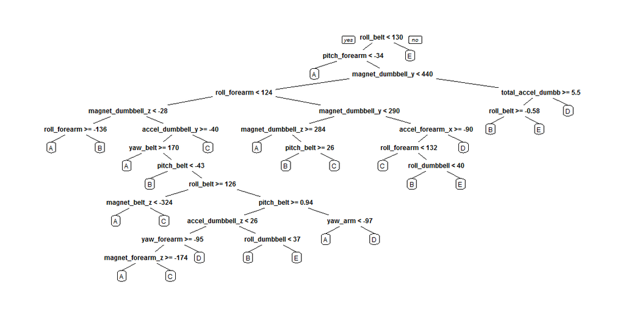

```r
treeplot <- rpart(classe ~ ., data=trainset, method="class")
prp(treeplot)
```

## Predicting with the test data

We apply this model to the test data we had downloaded earlier.

```r
result <- predict(modelfit, test[, -length(names(test))])
result
```

```
##  [1] B A B A A E D B A A B C B A E E A B B B
## Levels: A B C D E
```